# Decision Tree

## Introduction of Decision Tree

Classification is a two-step process, learning step and prediction step, in machine learning. In the learning step, the model is developed based on given training data. In the prediction step, the model is used to predict the response for given data. **Decision Tree** is one of the easiest and popular classification algorithms to understand and interpret.

Decision Tree algorithm belongs to the family of supervised learning algorithms. Unlike other supervised learning algorithms, the decision tree algorithm can be used for solving regression and classification problems too. The goal of using a Decision Tree is to create a training model that can use to predict the class or value of the target variable by learning simple decision rules inferred from prior data(training data). In Decision Trees, for predicting a class label for a record we start from the root of the tree. We compare the values of the root attribute with the record’s attribute. On the basis of comparison, we follow the branch corresponding to that value and jump to the next node.

## Dataset Introduction

#### New Dataset of Residential power usage 3 years data

There are two datasets in total. The power usage data, extracted from “TRIEAGLE ENERGY LP, The Woodlands, Texas 77393”. and the historical weather data for Houston, Texas extracted from “www.wunderground.com”

For the direction I want to study, I decided to use this new dataset is because i want to know how residence use energy in time series. And I can analysis the factors that influence residence’s decision in energy consumption. like maybe people will use more energy while snowing outside. Thus, this dataset is also useful in answering my ten questions about future energy usage.

## Objectives

1. Clean the dataset and do simple exploration  
   The dataset has not been cleaned in previous section since it is newly find out. In this section, I will clean it and use it to do some simple EDA.
2. Decision Tree The purpose of this section is to geneerate decision tree. And using the hyper-paramter tunning we learn from class to optimize the model. Then, graph the decision tree.

## Part 1 - Data Cleaning and Exploration

Load packages and dataset

```python
import pandas as pd
import os
import numpy as np
import pandas as pd
import re
from scipy import stats
from datetime import datetime
import matplotlib.pyplot as plt
import matplotlib
%matplotlib inline
import seaborn as sns
from sklearn.preprocessing import LabelEncoder
from sklearn.model_selection import train_test_split
from sklearn import tree

weather = pd.read_csv("/Users/crystal/Desktop/anly-501-project-HuitingSong/501-project-website/data/raw data/weather.csv",parse_dates = ['Date'])
weather.head()
```

|  | Date | Day | Temp_max | Temp_avg | Temp_min | Dew_max | Dew_avg | Dew_min | Hum_max | Hum_avg | Hum_min | Wind_max | Wind_avg | Wind_min | Press_max | Press_avg | Press_min | Precipit | day_of_week |
| --- | --- | --- | --- | --- | --- | --- | --- | --- | --- | --- | --- | --- | --- | --- | --- | --- | --- | --- | --- |
| 0 | 2016-01-06 | 1 | 85 | 74.8 | 68 | 74 | 71.4 | 66 | 100 | 89.4 | 65 | 21 | 9.5 | 0 | 29.8 | 29.8 | 29.7 | 0.00 | 2 |
| 1 | 2016-02-06 | 2 | 76 | 71.2 | 66 | 74 | 70.3 | 66 | 100 | 96.8 | 89 | 18 | 7.8 | 0 | 29.8 | 29.8 | 29.7 | 4.33 | 5 |
| 2 | 2016-03-06 | 3 | 79 | 72.1 | 68 | 72 | 70.0 | 68 | 100 | 93.6 | 72 | 18 | 4.7 | 0 | 29.8 | 29.8 | 29.7 | 3.18 | 6 |
| 3 | 2016-04-06 | 4 | 76 | 71.2 | 69 | 73 | 70.0 | 66 | 100 | 96.1 | 85 | 20 | 7.0 | 0 | 29.8 | 29.7 | 29.7 | 2.37 | 2 |
| 4 | 2016-05-06 | 5 | 82 | 73.8 | 68 | 72 | 70.0 | 68 | 100 | 88.7 | 62 | 17 | 7.7 | 0 | 29.7 | 29.7 | 29.7 | 0.39 | 4 |

```python
usage = pd.read_csv("/Users/crystal/Desktop/anly-501-project-HuitingSong/501-project-website/data/raw data/power_usage.csv")
usage.head()
```

|  | StartDate | Value (kWh) | day_of_week | notes |
| --- | --- | --- | --- | --- |
| 0 | 2016-01-06 00:00:00 | 1.057 | 2 | weekday |
| 1 | 2016-01-06 01:00:00 | 1.171 | 2 | weekday |
| 2 | 2016-01-06 02:00:00 | 0.560 | 2 | weekday |
| 3 | 2016-01-06 03:00:00 | 0.828 | 2 | weekday |
| 4 | 2016-01-06 04:00:00 | 0.932 | 2 | weekday |

splite the datetime stamp into date and time sperately

```python
usage['Date'] = pd.to_datetime(usage["StartDate"]).dt.date
usage['Date'] = pd.to_datetime(usage['Date'])
usage['time'] = pd.to_datetime(usage["StartDate"]).dt.time
usage.drop('StartDate' , axis =1, inplace= True)
usage.drop('day_of_week' , axis =1, inplace= True)
usage.head()
```

|  | Value (kWh) | notes | Date | time |
| --- | --- | --- | --- | --- |
| 0 | 1.057 | weekday | 2016-01-06 | 00:00:00 |
| 1 | 1.171 | weekday | 2016-01-06 | 01:00:00 |
| 2 | 0.560 | weekday | 2016-01-06 | 02:00:00 |
| 3 | 0.828 | weekday | 2016-01-06 | 03:00:00 |
| 4 | 0.932 | weekday | 2016-01-06 | 04:00:00 |

merge two dataset by date

```python
merged = usage.merge(weather, on='Date', how='left')#.drop('date', axis=1)
merged['year'] = merged['Date'].dt.year
merged.head()
```

|  | Value (kWh) | notes | Date | time | Day | Temp_max | Temp_avg | Temp_min | Dew_max | Dew_avg | ... | Hum_min | Wind_max | Wind_avg | Wind_min | Press_max | Press_avg | Press_min | Precipit | day_of_week | year |
| --- | --- | --- | --- | --- | --- | --- | --- | --- | --- | --- | --- | --- | --- | --- | --- | --- | --- | --- | --- | --- | --- |
| 0 | 1.057 | weekday | 2016-01-06 | 00:00:00 | 1 | 85 | 74.8 | 68 | 74 | 71.4 | ... | 65 | 21 | 9.5 | 0 | 29.8 | 29.8 | 29.7 | 0.0 | 2 | 2016 |
| 1 | 1.171 | weekday | 2016-01-06 | 01:00:00 | 1 | 85 | 74.8 | 68 | 74 | 71.4 | ... | 65 | 21 | 9.5 | 0 | 29.8 | 29.8 | 29.7 | 0.0 | 2 | 2016 |
| 2 | 0.560 | weekday | 2016-01-06 | 02:00:00 | 1 | 85 | 74.8 | 68 | 74 | 71.4 | ... | 65 | 21 | 9.5 | 0 | 29.8 | 29.8 | 29.7 | 0.0 | 2 | 2016 |
| 3 | 0.828 | weekday | 2016-01-06 | 03:00:00 | 1 | 85 | 74.8 | 68 | 74 | 71.4 | ... | 65 | 21 | 9.5 | 0 | 29.8 | 29.8 | 29.7 | 0.0 | 2 | 2016 |
| 4 | 0.932 | weekday | 2016-01-06 | 04:00:00 | 1 | 85 | 74.8 | 68 | 74 | 71.4 | ... | 65 | 21 | 9.5 | 0 | 29.8 | 29.8 | 29.7 | 0.0 | 2 | 2016 |

5 rows × 23 columns

check the null value and save the merged datatset

```python
merged.isnull().sum() # no null value
merged.to_csv("/Users/crystal/Desktop/anly-501-project-HuitingSong/501-project-website/data/cleaned data/merged_w_u.csv")
```

barplot to show the daily energy usage value in kWh

from the graph, seems like the daily energy does not change to much. Even thought do not know the reasons why people in day 22 to day 28 use less energy than other day, this may be a good signal that reducing the energy consumption.

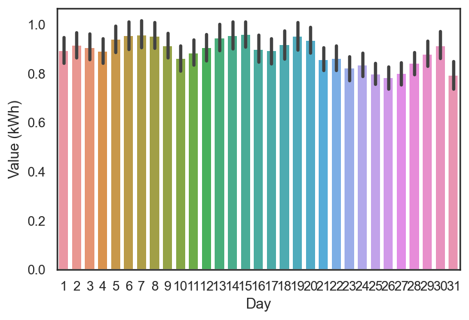

```python
sns.barplot(x=merged["Day"], y=merged["Value (kWh)"])
plt.show()
```

scatter plot to how average temperature influence the energy consumpion in kWh

As we can see, the higher then temperature in average, the more energy consumption. The distribution looks extremely skrew to the left.

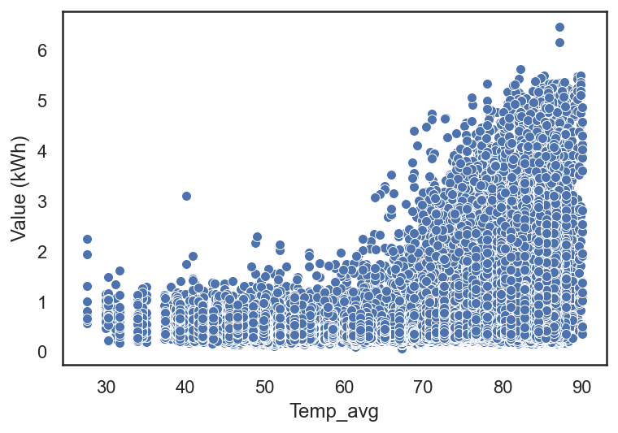

```python
sns.scatterplot(x=merged["Temp_avg"], y=merged["Value (kWh)"])
```

barplot to show the yearly energy usage.

2016 has the highest energy consumption, but then 2017 turned to be second lowest. There must be something happened for this abnormal situation.

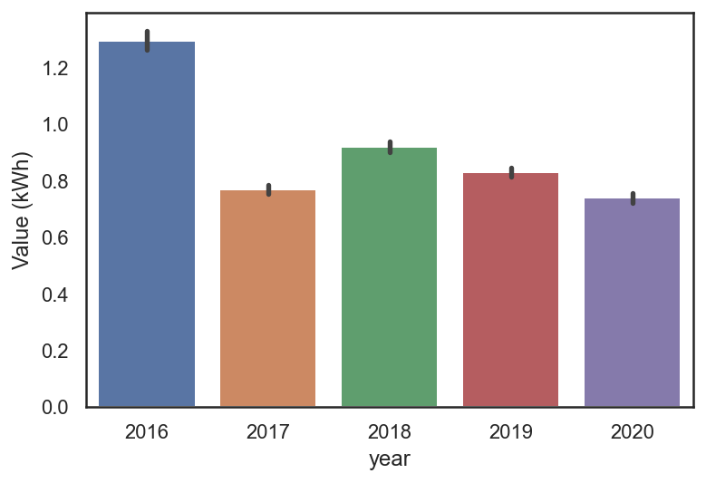

```python
sns.barplot(x=merged["year"], y=merged["Value (kWh)"], )
plt.show()
```

barplot to show energy usage in different notes

from the notes and graph, we can see during the Covid lockdown,the energy usage did not drop dramatically. compare with the situation of lowest energy usage in 2020 in the last step of yearly usage, Covid lockdown does not contribute the energy save much. And, when in vacation, people use less energy. Maybe most of people will choose to go out, the energy in building will goes lower at that period.

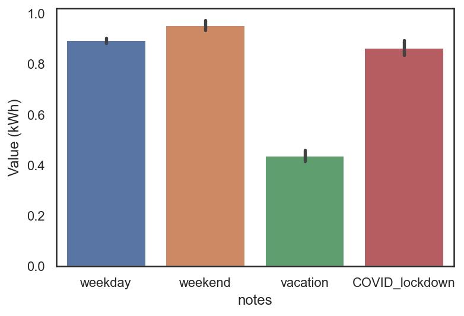

```python
sns.barplot(x=merged["notes"], y=merged["Value (kWh)"], )
plt.show()
```

Information of dataset

from the basic info of energy comsumption in kWh, the average usage is about 0.89 kWh. and the median is 0.501. the middle 50% people consume between 0.32 to 1.07.

```python
print("the mean of energy usage is: ",merged["Value (kWh)"].mean() )
print("the median energy usage is:",merged["Value (kWh)"].median())
print("the percentile of energy usage is:",np.percentile(merged["Value (kWh)"],[25,50,75]))
print("the maximum of energy usage is: ",merged["Value (kWh)"].max() )
print("the minimum of energy usage is: ",merged["Value (kWh)"].min() )
```

```
the mean of energy usage is:  0.8916311668904373
the median energy usage is: 0.501
the percentile of energy usage is: [0.32375 0.501   1.072  ]
the maximum of energy usage is:  6.446000000000001
the minimum of energy usage is:  0.064
```

Thus, from the EDA, we can see that the energy consumption can be influenced by many factors. These indicate that the energy consumption is hard to be tracked. If we change the time frame and count methods, the energy usage will be shown differenly, but in all, the dataset shows that the daily-based usage of energy is not much different. These may indicate that the behavior of residences does not change dramatically in daily and they are using the energy in a proper way.

```python
# value
bins = [0,1.5,6.5]
merged['group'] = pd.cut(merged['Value (kWh)'], bins)
lbl=LabelEncoder()
merged['usage'] = lbl.fit_transform(merged['group'])
df = merged.drop(['Value (kWh)','group'],axis=1)

# notes
from sklearn.preprocessing import LabelEncoder
le = LabelEncoder()
label = le.fit_transform(df['notes'])
label
df["note"] = label
```

saved dataset for future use

```python
df = df.drop(['notes',"time","Date"], axis='columns')
df.to_csv("/Users/crystal/Desktop/anly-501-project-HuitingSong/501-project-website/data/cleaned data/categorize_usage.csv")
df.head()
```

|  | Day | Temp_max | Temp_avg | Temp_min | Dew_max | Dew_avg | Dew_min | Hum_max | Hum_avg | Hum_min | ... | Wind_avg | Wind_min | Press_max | Press_avg | Press_min | Precipit | day_of_week | year | usage | note |
| --- | --- | --- | --- | --- | --- | --- | --- | --- | --- | --- | --- | --- | --- | --- | --- | --- | --- | --- | --- | --- | --- |
| 0 | 1 | 85 | 74.8 | 68 | 74 | 71.4 | 66 | 100 | 89.4 | 65 | ... | 9.5 | 0 | 29.8 | 29.8 | 29.7 | 0.0 | 2 | 2016 | 0 | 2 |
| 1 | 1 | 85 | 74.8 | 68 | 74 | 71.4 | 66 | 100 | 89.4 | 65 | ... | 9.5 | 0 | 29.8 | 29.8 | 29.7 | 0.0 | 2 | 2016 | 0 | 2 |
| 2 | 1 | 85 | 74.8 | 68 | 74 | 71.4 | 66 | 100 | 89.4 | 65 | ... | 9.5 | 0 | 29.8 | 29.8 | 29.7 | 0.0 | 2 | 2016 | 0 | 2 |
| 3 | 1 | 85 | 74.8 | 68 | 74 | 71.4 | 66 | 100 | 89.4 | 65 | ... | 9.5 | 0 | 29.8 | 29.8 | 29.7 | 0.0 | 2 | 2016 | 0 | 2 |
| 4 | 1 | 85 | 74.8 | 68 | 74 | 71.4 | 66 | 100 | 89.4 | 65 | ... | 9.5 | 0 | 29.8 | 29.8 | 29.7 | 0.0 | 2 | 2016 | 0 | 2 |

5 rows × 21 columns

Generate a correlation matrix to see the relationship between each variables.

```
(21, 21)
```

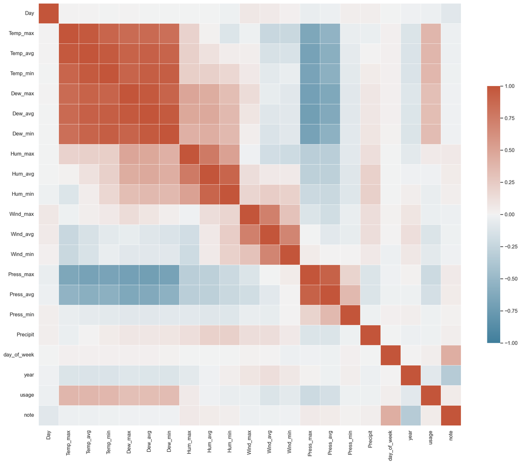

```python
corr = df.corr();  #print(corr)                 #COMPUTE CORRELATION OF FEATER MATRIX
print(corr.shape)
sns.set_theme(style="white")
f, ax = plt.subplots(figsize=(20, 20))  # Set up the matplotlib figure
cmap = sns.diverging_palette(230, 20, as_cmap=True)     # Generate a custom diverging colormap
# Draw the heatmap with the mask and correct aspect ratio
sns.heatmap(corr,  cmap=cmap, vmin=-1, vmax=1, center=0, square=True, linewidths=.5, cbar_kws={"shrink": .5})
plt.show()
```

histogram to see the counts of each categories.

Most of residential usage is low statue which is under 1.5 kWh.

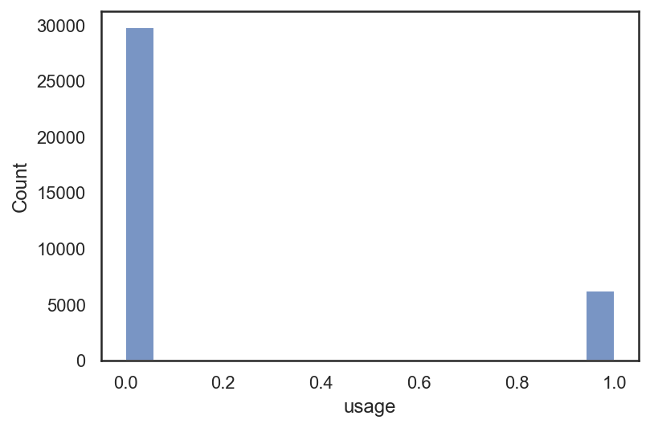

```python
sns.histplot(df["usage"])
```

## Part 2- Decision tree

since energy consumption can be influenced by alot. in this part, i will split the train and test set. also, the `usage` variable will be the target column and other variables will be stored together.

```python
y = df['usage']
X = df.drop(['usage'],axis=1)
cols = []
for col in X:
    cols.append(col)

X = X.to_numpy()

x_train,x_test,y_train,y_test=train_test_split(X,y,test_size=0.2,random_state=0)
```

Train the model

I use the function from scikit-learn packages

```python
model = tree.DecisionTreeClassifier()
model = model.fit(x_train,y_train)
```

get the predicted value from test and train set

```python
yp_train = model.predict(x_train)
yp_test = model.predict(x_test)
```

Plot the confusion matrix and get the model accuracy

```
------TRAINING------
ACCURACY: 0.8432599700983971
NEGATIVE RECALL (Y=0): 0.966098843322818
NEGATIVE PRECISION (Y=0): 0.861197555397248
POSITIVE RECALL (Y=1): 0.2575210589651023
POSITIVE PRECISION(Y=1): 0.614354066985646
[[22969   806]
 [ 3702  1284]]
```

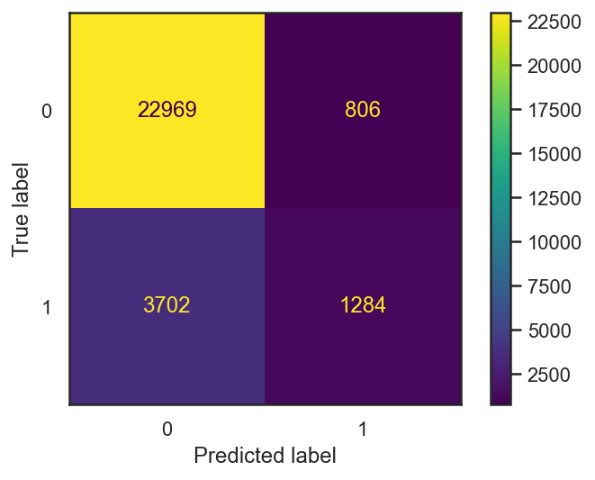

```
------TEST------
ACCURACY: 0.8286747323042692
NEGATIVE RECALL (Y=0): 0.9501755559271025
NEGATIVE PRECISION (Y=0): 0.8588484207344718
POSITIVE RECALL (Y=1): 0.228099173553719
POSITIVE PRECISION(Y=1): 0.4808362369337979
[[5683  298]
 [ 934  276]]
```

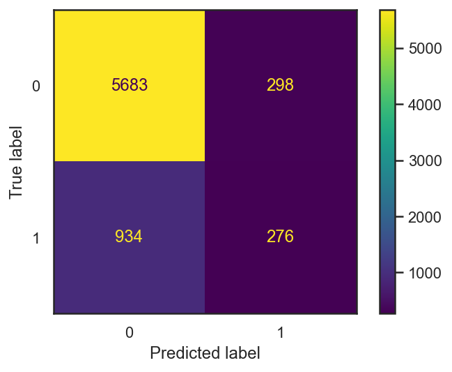

```python
from sklearn.metrics import confusion_matrix
from sklearn.metrics import ConfusionMatrixDisplay
from sklearn.metrics import accuracy_score
from sklearn.metrics import precision_score
from sklearn.metrics import recall_score
from sklearn import tree
from sklearn.metrics import classification_report
from IPython.display import Image
from sklearn.ensemble import RandomForestClassifier
from sklearn.inspection import permutation_importance
def confusion_plot(y_test,yp_test):
    print("ACCURACY:",accuracy_score(y_test,yp_test))
    print("NEGATIVE RECALL (Y=0):",recall_score(y_test, yp_test, pos_label = 0))
    print("NEGATIVE PRECISION (Y=0):",precision_score(y_test,yp_test, pos_label= 0))
    print("POSITIVE RECALL (Y=1):",recall_score(y_test,yp_test))
    print("POSITIVE PRECISION(Y=1):",precision_score(y_test,yp_test))
    print(confusion_matrix(y_test,yp_test))
    ConfusionMatrixDisplay.from_predictions(y_test, yp_test)
    plt.show()

print("------TRAINING------")
confusion_plot(y_train,yp_train)
print("------TEST------")
confusion_plot(y_test,yp_test)
```

plot the decision tree

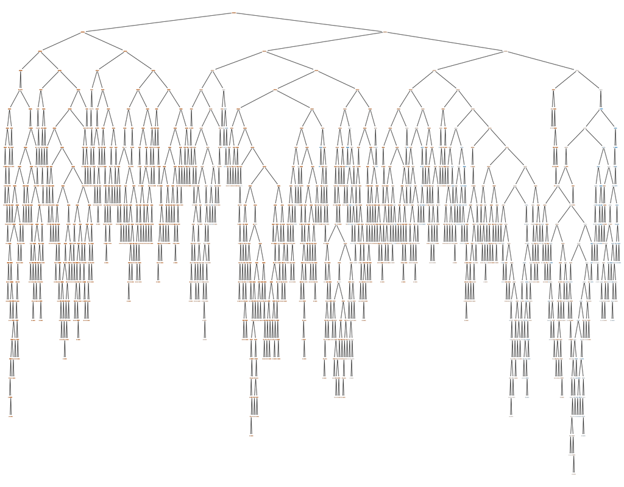

```python
def plot_tree(model,X,Y):
    fig = plt.figure(figsize=(25,20))
    _ = tree.plot_tree(model,filled=True)
plot_tree(model,X,y)
```

Opitimization

using hyper-parameter tuning to iterate over max_depth to get the optimize the model training.

```
   0         1         2        3
0  1  0.831734  1.000000  0.00000
1  2  0.831734  1.000000  0.00000
2  3  0.831734  1.000000  0.00000
3  4  0.831734  1.000000  0.00000
4  5  0.831873  0.997325  0.01405
   0         1         2         3
0  1  0.826640  1.000000  0.000000
1  2  0.826640  1.000000  0.000000
2  3  0.826640  1.000000  0.000000
3  4  0.826640  1.000000  0.000000
4  5  0.827579  0.998233  0.013839
```

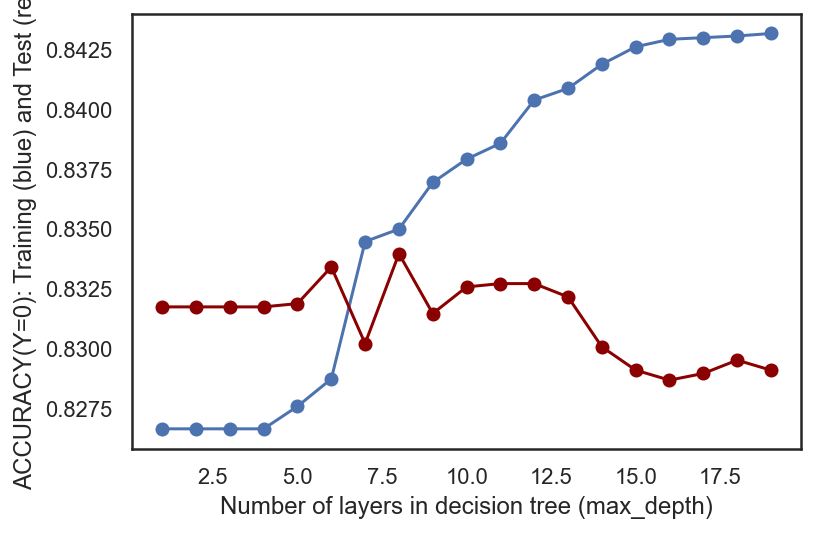

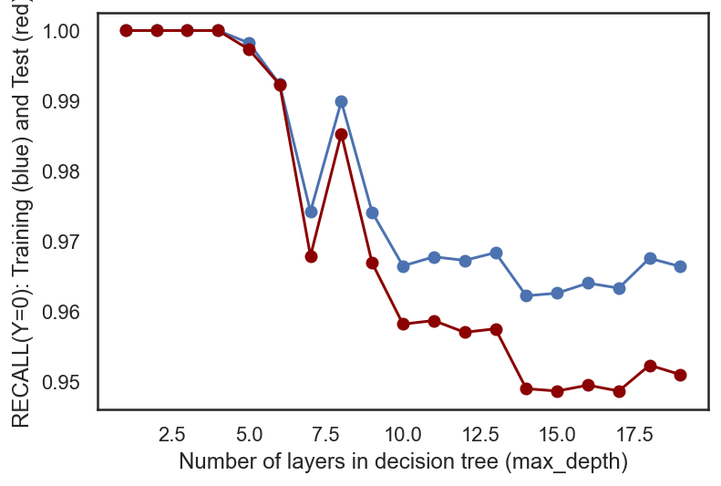

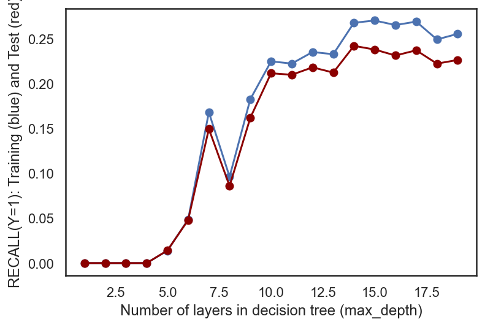

```python
test_results=[]
train_results=[]

for num_layer in range(1,20):
    model = tree.DecisionTreeClassifier(max_depth=num_layer)
    model = model.fit(x_train,y_train)

    yp_train=model.predict(x_train)
    yp_test=model.predict(x_test)

    # print(y_pred.shape)
    test_results.append([num_layer,accuracy_score(y_test, yp_test),recall_score(y_test, yp_test,pos_label=0),recall_score(y_test, yp_test,pos_label=1)])
    train_results.append([num_layer,accuracy_score(y_train, yp_train),recall_score(y_train, yp_train,pos_label=0),recall_score(y_train, yp_train,pos_label=1)])

test_results = pd.DataFrame(test_results)
train_results = pd.DataFrame(train_results)

print(test_results.head())
print(train_results.head())


plt.plot(train_results[0],train_results[1],'-o')
plt.plot(test_results[0],test_results[1],'-o',color = 'darkred')
plt.xlabel("Number of layers in decision tree (max_depth)")
plt.ylabel("ACCURACY(Y=0): Training (blue) and Test (red)")
plt.show()

plt.plot(train_results[0],train_results[2],'-o')
plt.plot(test_results[0],test_results[2],'-o',color = 'darkred')
plt.xlabel("Number of layers in decision tree (max_depth)")
plt.ylabel("RECALL(Y=0): Training (blue) and Test (red)")
plt.show()

plt.plot(train_results[0],train_results[3],'-o')
plt.plot(test_results[0],test_results[3],'-o',color = 'darkred')
plt.xlabel("Number of layers in decision tree (max_depth)")
plt.ylabel("RECALL(Y=1): Training (blue) and Test (red)")
plt.show()
```

from the optimization and training result, we can see the accuracy of model has been advanced.

retrain the model by choosing max_depth=8

```
------TRAINING------
ACCURACY: 0.8349848753520392
NEGATIVE RECALL (Y=0): 0.9899053627760253
NEGATIVE PRECISION (Y=0): 0.8393067294319033
POSITIVE RECALL (Y=1): 0.09626955475330927
POSITIVE PRECISION(Y=1): 0.6666666666666666
[[23535   240]
 [ 4506   480]]
```

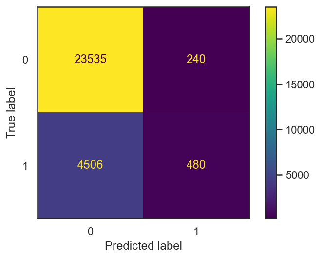

```
------TEST------
ACCURACY: 0.833959115561118
NEGATIVE RECALL (Y=0): 0.9852867413476007
NEGATIVE PRECISION (Y=0): 0.841977425346478
POSITIVE RECALL (Y=1): 0.0859504132231405
POSITIVE PRECISION(Y=1): 0.5416666666666666
[[5893   88]
 [1106  104]]
```

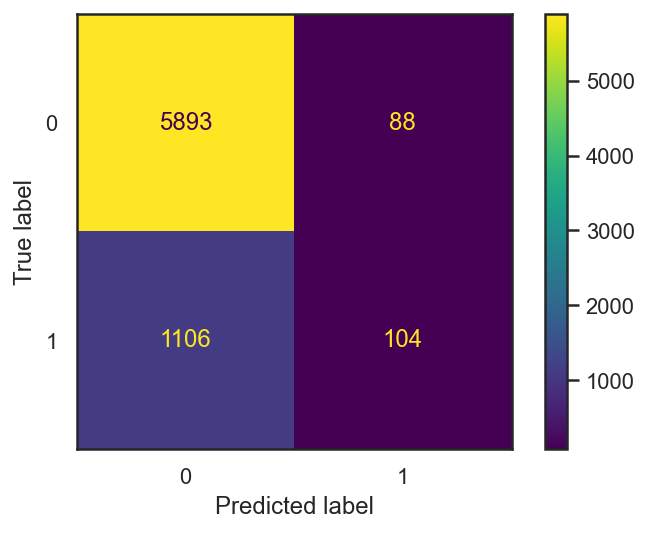

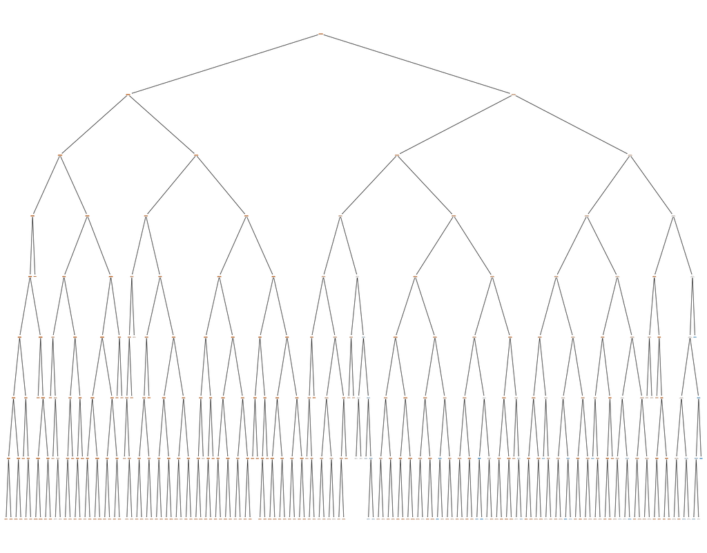

```python
from sklearn import tree
model = tree.DecisionTreeClassifier(max_depth=8)
model = model.fit(x_train,y_train)

yp_train=model.predict(x_train)
yp_test=model.predict(x_test)

print("------TRAINING------")
confusion_plot(y_train,yp_train)
print("------TEST------")
confusion_plot(y_test,yp_test)

plot_tree(model,X,y)
```